# **Amazon Product Recommendation System**

# Loading and Exploring the dataset

Loading the necessary libraries

```python
import warnings
import pandas as pd
import numpy as np
import matplotlib.pyplot as plt
import seaborn as sns
from collections import defaultdict
from sklearn.metrics import mean_squared_error
```

Given the issues faced while trying to mount the dataset from the drive becuase of how big the dataset is, using gdown library to fetch the dataset was a valuable option

```python
import gdown
gdown.download("https://drive.google.com/uc?id=1XahZcR287ke7j48I7-oj0KzmmwSSvA3Y", "dataset.csv", quiet=False)
df = pd.read_csv("dataset.csv", header=None, names=["userid", "product_id", "rating", "timestamp"])

df.head()
```

```
Downloading...
From (original): https://drive.google.com/uc?id=1XahZcR287ke7j48I7-oj0KzmmwSSvA3Y
From (redirected): https://drive.google.com/uc?id=1XahZcR287ke7j48I7-oj0KzmmwSSvA3Y&confirm=t&uuid=61a5e632-a9a8-424b-99bf-0073d93e8e86
To: C:\Users\aae2082\dataset.csv
```

|  | userid | product_id | rating | timestamp |
| --- | --- | --- | --- | --- |
| 0 | AKM1MP6P0OYPR | 0132793040 | 5.0 | 1365811200 |
| 1 | A2CX7LUOHB2NDG | 0321732944 | 5.0 | 1341100800 |
| 2 | A2NWSAGRHCP8N5 | 0439886341 | 1.0 | 1367193600 |
| 3 | A2WNBOD3WNDNKT | 0439886341 | 3.0 | 1374451200 |
| 4 | A1GI0U4ZRJA8WN | 0439886341 | 1.0 | 1334707200 |

# Exploring the dataset and performing EDA

```python
df.info()
```

```
<class 'pandas.core.frame.DataFrame'>
RangeIndex: 7824482 entries, 0 to 7824481
Data columns (total 4 columns):
 #   Column      Dtype
---  ------      -----
 0   userid      object
 1   product_id  object
 2   rating      float64
 3   timestamp   int64
dtypes: float64(1), int64(1), object(2)
memory usage: 238.8+ MB
```

**There are 4 columns in the data set and 7,824,482 rows/observations** **After Observing the dataset, we can conculde that Timestamp is not needed in the data analysis process, hence we can drop this column**

```python
df = df.drop(['timestamp'], axis = 1)
```

### Here, we will be taking users who have given at least 50 ratings, and the products that have at least 5 ratings, as when we shop online we prefer to have some number of ratings of a product.

```python
users = df.userid

ratings_count = dict()
for user in users:
            if user in ratings_count:
                ratings_count[user] += 1
            else:
                ratings_count[user] = 1
```

```python
RATINGS_CUTOFF = 50

remove_users = []

for user, num_ratings in ratings_count.items():
    if num_ratings < RATINGS_CUTOFF:
        remove_users.append(user)

df = df.loc[ ~ df.userid.isin(remove_users)]
```

```python
prods = df.product_id


ratings_count = dict()

for prod in prods:


    if prod in ratings_count:
        ratings_count[prod] += 1


    else:
        ratings_count[prod] = 1
```

```python
RATINGS_CUTOFF = 5

remove_users = []

for user, num_ratings in ratings_count.items():
    if num_ratings < RATINGS_CUTOFF:
        remove_users.append(user)

df_final = df.loc[~ df.product_id.isin(remove_users)]
```

```python
# Print a few rows of the imported dataset
df_final
df = df_final
```

```python
# Check the number of rows and columns and provide observations
df.info()
```

```
<class 'pandas.core.frame.DataFrame'>
Index: 65290 entries, 1310 to 7824427
Data columns (total 3 columns):
 #   Column      Non-Null Count  Dtype
---  ------      --------------  -----
 0   userid      65290 non-null  object
 1   product_id  65290 non-null  object
 2   rating      65290 non-null  float64
dtypes: float64(1), object(2)
memory usage: 2.0+ MB
```

```python
print("=== SHAPE ===")
print(df.shape)

print("\n=== DTYPES ===")
print(df.dtypes)

print("\n=== MISSING VALUES ===")
print(df.isnull().sum())

print("\n=== DUPLICATES ===")
print(df.duplicated().sum())

print("\n=== RATING STATS ===")
print(df["rating"].describe())

print("\n=== RATING VALUE COUNTS ===")
print(df["rating"].value_counts().sort_index())
```

```
=== SHAPE ===
(65290, 3)

=== DTYPES ===
userid         object
product_id     object
rating        float64
dtype: object

=== MISSING VALUES ===
userid        0
product_id    0
rating        0
dtype: int64

=== DUPLICATES ===
0

=== RATING STATS ===
count    65290.000000
mean         4.294808
std          0.988915
min          1.000000
25%          4.000000
50%          5.000000
75%          5.000000
max          5.000000
Name: rating, dtype: float64

=== RATING VALUE COUNTS ===
rating
1.0     1852
2.0     2515
3.0     6481
4.0    18127
5.0    36315
Name: count, dtype: int64
```

There are 65K observations, and 3 columns.

There are 2 object data types (userid and product id) and rating as float

There are no missing values in the dataset

The are no duplicates in the dataset

The mean for the ratings is 4.29, min 1, and max is 5

```python
df.head()
```

|  | userid | product_id | rating |
| --- | --- | --- | --- |
| 1310 | A3LDPF5FMB782Z | 1400501466 | 5.0 |
| 1322 | A1A5KUIIIHFF4U | 1400501466 | 1.0 |
| 1335 | A2XIOXRRYX0KZY | 1400501466 | 3.0 |
| 1451 | AW3LX47IHPFRL | 1400501466 | 5.0 |
| 1456 | A1E3OB6QMBKRYZ | 1400501466 | 1.0 |

```python
print(df['userid'].nunique())
print(df['product_id'].nunique())
```

```
1540
5689
```

There are 1540 unique users and 5689 unique products As per the number of unique users and products, there is a possibility of 1540 * 5689 = about 8.7M rating, which is not the case, because we have only around 65K rating. Hence, not every user has rated every product in the dataset, which is understandable

```python
df.groupby(['userid', 'product_id']).count()
```

| userid | product_id | rating |
| --- | --- | --- |
| A100UD67AHFODS | B00004Z5M1 | 1 |
|  | B0001D3K8A | 1 |
|  | B000233WJ6 | 1 |
|  | B0002KVQBA | 1 |
|  | B0002SQ2P2 | 1 |
| ... | ... | ... |
| AZOK5STV85FBJ | B005PQTYHE | 1 |
|  | B006MPRFJQ | 1 |
|  | B00AANMVNQ | 1 |
|  | B00B25P27S | 1 |
|  | B00FB2XNCE | 1 |

65290 rows × 1 columns

```python
df.groupby(['userid', 'product_id']).count()['rating'].sum()
```

```
65290
```

the sum is equal to the total number of observations, which states that there is only one interaction between a pair of a product and a user

```python
df['userid'].value_counts()
```

```
userid
ADLVFFE4VBT8      295
A3OXHLG6DIBRW8    230
A1ODOGXEYECQQ8    217
A36K2N527TXXJN    212
A25C2M3QF9G7OQ    203
                 ...
A16CVJUQOB6GIB      2
A2BGZ52M908MJY      2
A3DL29NLZ7SXXG      1
AP2NZAALUQKF5       1
A3MV1KKHX51FYT      1
Name: count, Length: 1540, dtype: int64
```

```python
df['product_id'].value_counts()
```

```
product_id
B0088CJT4U    206
B003ES5ZUU    184
B000N99BBC    167
B007WTAJTO    164
B00829TIEK    149
             ...
B00368CDH6      5
B0036AZA6A      5
B0036E8V08      5
B0036QL1JY      5
B00LGQ6HL8      5
Name: count, Length: 5689, dtype: int64
```

```python
print(df["rating"].value_counts().sort_index())
print(f"\nRatings outside 1-5: {(~df['rating'].between(1, 5)).sum()}")
```

```
rating
1.0     1852
2.0     2515
3.0     6481
4.0    18127
5.0    36315
Name: count, dtype: int64

Ratings outside 1-5: 0
```

The product with product id B0088CJT4U has been rated by 206 users out of 1540 users which is good, but we still have 1334 who havent been rated. for these 1334 users we can build a recommendation system to predict who is going to interact with this product buy or view

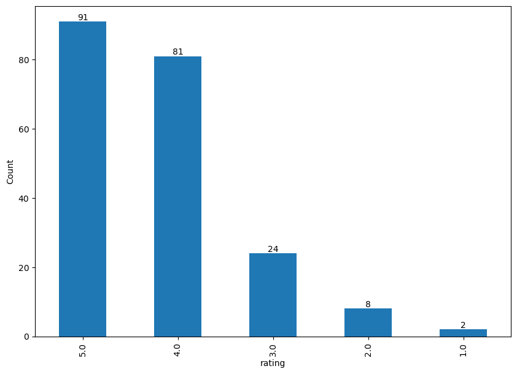

```python
plt.figure(figsize=(10,7))
label = df[df['product_id'] == 'B0088CJT4U']['rating'].value_counts().plot(kind = 'bar')
label.bar_label(label.containers[0], fmt='%d', label_type='edge')
plt.xlabel('rating')
plt.ylabel('Count')
plt.show()
```

The product has been liked by the majority of the users, as the count of 5 and 4 is higher than the count of lower rating by significant amount

```python
df['userid'].value_counts()
```

```
userid
ADLVFFE4VBT8      295
A3OXHLG6DIBRW8    230
A1ODOGXEYECQQ8    217
A36K2N527TXXJN    212
A25C2M3QF9G7OQ    203
                 ...
A16CVJUQOB6GIB      2
A2BGZ52M908MJY      2
A3DL29NLZ7SXXG      1
AP2NZAALUQKF5       1
A3MV1KKHX51FYT      1
Name: count, Length: 1540, dtype: int64
```

User with userid: ADLVFFE4VBT8 has rated with the most numbers of products, 295 Still, we have signifiant amount of products with no ratings, we can build a recommendation system to predict which products are most likely to be viewed by the user.

the average number of product interactions per user varies widely from 1 to 295, which could present skewness to the charts

Lets count the user-product interactions in the dataset

```python
Count_Inter = df.groupby('userid').count()['product_id']
Count_Inter
```

```
userid
A100UD67AHFODS     53
A100WO06OQR8BQ     77
A105S56ODHGJEK     58
A105TOJ6LTVMBG     32
A10AFVU66A79Y1     47
                 ...
AZBXKUH4AIW3X      22
AZCE11PSTCH1L      23
AZMY6E8B52L2T     105
AZNUHQSHZHSUE      30
AZOK5STV85FBJ      14
Name: product_id, Length: 1540, dtype: int64
```

# Model 1: Rank-Based Recommendation System

The rank based recommendation system is a good approach for for everyone with no personalization, we can show what most people liked. Its best for new users with no history of rating, but it still lacks personalization

It is also useful when we have a cold start problem. where we get a new user into the system and the machine is not able to recommend products to them.

```python
average_rating = df.groupby('product_id')['rating'].mean()
count_rating = df.groupby('product_id')['rating'].count()

#make a dataframe with the count and the average of ratings

final_rating = pd.DataFrame({'avg_rating': average_rating, 'rating_count': count_rating})
```

```python
final_rating.head()
```

| product_id | avg_rating | rating_count |
| --- | --- | --- |
| 1400501466 | 3.333333 | 6 |
| 1400532655 | 3.833333 | 6 |
| 1400599997 | 4.000000 | 5 |
| 9983891212 | 4.875000 | 8 |
| B00000DM9W | 5.000000 | 5 |

Next, i will create a function to find the top n products for a recommendation based on the average ratings of products. in additon, i will add a threshold for a minimum number of interactions for a product to be considered.

```python
def top_nproducts(data, n, min_interaction = 100):
  recommendations = data[data['rating_count'] > min_interaction]
  recommendations = recommendations.sort_values(by = 'avg_rating', ascending = False)
  return recommendations.index[:n]
```

Recommending 10 products with 50 minimum interactions based on popularity

```python
list(top_nproducts(final_rating, 10, 50))
```

```
['B001TH7GUU',
 'B003ES5ZUU',
 'B0019EHU8G',
 'B006W8U2MU',
 'B000QUUFRW',
 'B000HPV3RW',
 'B001TH7GSW',
 'B000BQ7GW8',
 'B000N99BBC',
 'B002WE6D44']
```

```python
list(top_nproducts(final_rating, 10, 100))
```

```
['B003ES5ZUU',
 'B000N99BBC',
 'B007WTAJTO',
 'B002V88HFE',
 'B004CLYEDC',
 'B00834SJSK',
 'B0034CL2ZI',
 'B00834SJNA',
 'B00829TIEK',
 'B00829THK0']
```

```python
list(top_nproducts(final_rating, 10, 200))
```

```
['B0088CJT4U']
```

Trying the Recommending system to get 10 products with minimum interactions of 200, we end up with only 1 product, which we created the chart for earlier. a quick check to make sure the data is valid

Now lets explore other methods of the recommendation systems, lets start with Collaborative filtering based recommendation systems.

# Building user-user similarity/neighborhood based collaborative filtering

for this model, we will find users who are similar to the current user using cosine, or MSD distance, then recommend what those similar user liked. then we can tune the model with GridSearchCV over K(neighbors), the downside for this approach is the performance with new or rare users could be weak as there will be challenging to calculate the MSD or Cosine distance

## Importing the needed libraries

```python
from surprise import accuracy
from surprise.reader import Reader
from surprise.dataset import Dataset
from surprise.model_selection import GridSearchCV
from surprise.model_selection import train_test_split
from surprise.prediction_algorithms.knns import KNNBasic
from surprise.prediction_algorithms.matrix_factorization import SVD
from surprise.model_selection import KFold
from surprise import CoClustering
```

#### Next, i will create a useful function to take the recommendation model as input and gives the precision@k, recall@k and F-1score@k for that model - these metrics will show if the relevant item is recommended item, and if the recommended item is relevant, in addition, for F-1 score to measure the accuracy of the model.

```python
def precision_recall_at_k(model, k = 10, threshold = 3.5):
    """Return precision and recall at k metrics for each user"""

    # First map the predictions to each user
    user_est_true = defaultdict(list)

    # Making predictions on the test data
    predictions = model.test(testset)

    for uid, _, true_r, est, _ in predictions:
        user_est_true[uid].append((est, true_r))

    precisions = dict()
    recalls = dict()
    for uid, user_ratings in user_est_true.items():

        # Sort user ratings by estimated value
        user_ratings.sort(key = lambda x: x[0], reverse = True)

        # Number of relevant items
        n_rel = sum((true_r >= threshold) for (_, true_r) in user_ratings)

        # Number of recommended items in top k
        n_rec_k = sum((est >= threshold) for (est, _) in user_ratings[:k])

        # Number of relevant and recommended items in top k
        n_rel_and_rec_k = sum(((true_r >= threshold) and (est >= threshold))
                              for (est, true_r) in user_ratings[:k])

        # Precision@K: Proportion of recommended items that are relevant
        # When n_rec_k is 0, Precision is undefined. Therefore, we are setting Precision to 0 when n_rec_k is 0

        precisions[uid] = n_rel_and_rec_k / n_rec_k if n_rec_k != 0 else 0

        # Recall@K: Proportion of relevant items that are recommended
        # When n_rel is 0, Recall is undefined. Therefore, we are setting Recall to 0 when n_rel is 0

        recalls[uid] = n_rel_and_rec_k / n_rel if n_rel != 0 else 0

    # Mean of all the predicted precisions are calculated
    precision = round((sum(prec for prec in precisions.values()) / len(precisions)), 3)

    # Mean of all the predicted recalls are calculated
    recall = round((sum(rec for rec in recalls.values()) / len(recalls)), 3)

    accuracy.rmse(predictions)

    print('Precision: ', precision) # Command to print the overall precision

    print('Recall: ', recall) # Command to print the overall recall

    print('F_1 score: ', round((2*precision*recall)/(precision+recall), 3)) # Formula to compute the F-1 score
```

below, we are converting the df dataset which is a pandas dataframe into a different format called suprise.dataset. this is required for compatibility of the DF and the model

```python
reader = Reader(rating_scale = (0,5))
data = Dataset.load_from_df(df[['userid', 'product_id', 'rating']], reader)
trainset, testset = train_test_split(data, test_size = 0.2, random_state = 42)
```

```python
sim_options = {'name':'cosine',
              'user_based': True}

sim_user_user = KNNBasic(sim_options = sim_options, verbose = False, random_state = 1)
sim_user_user.fit(trainset)
precision_recall_at_k(sim_user_user)
```

```
RMSE: 1.0012
Precision:  0.855
Recall:  0.858
F_1 score:  0.856
```

We calculated RMSE to check how far the overall predicted ratings are from the actial ratings

F-1 score if 0.856, it indicates that mostly recommended products were relevant and relevant products were recommended.

we will try to improve by GridSearchCV by tunning different hyperparameters.